# **Homework 1: Spatial AutoCorrelation**

Anjelica Martinez

## **I. Preparation**

**I1. Load libraries and data**

```python
# Import libraries used for spatial data handling, analysis, and visualization
import geopandas as gpd           # handling geospatial vector data
import numpy as np                # numerical operations
import pandas as pd               # data manipulation
from libpysal.graph import Graph  # spatial weights / neighborhood graphs
import esda                       # exploratory spatial data analysis (LISA)
import matplotlib.pyplot as plt   # plotting

# Set a random seed to ensure reproducible results
from numpy.random import seed
seed(42)
```

**I2. Read the map file**

```python
# Save peru map file from github url to this variable
LinkPeru="https://raw.githubusercontent.com/DACSS-Anjelica/Homework_1/main/PeruMaps.gpkg"

# read the same layer used in the tutorial
peru = gpd.read_file(LinkPeru, layer='good_geom')

# Confirms it loaded correctly
peru.head()
```

|  | DEPARTAMENTO | PROVINCIA | DISTRITO | ubigeo | Poblacion | IDH2019 | Educ_sec_comp2019_pct | NBI2017_pct | Viv_sin_serv_hig2017_pct | geometry |
| --- | --- | --- | --- | --- | --- | --- | --- | --- | --- | --- |
| 0 | Apurimac | ABANCAY | ABANCAY | PE030101 | 56871 | 0.600375 | 78.865450 | 15.8 | 2.9 | MULTIPOLYGON (((-72.93158 -13.55616, -72.9314 ... |
| 1 | Ancash | BOLOGNESI | ABELARDO PARDO LEZAMETA | PE020502 | 1263 | 0.434687 | 50.434603 | 33.6 | 25.4 | MULTIPOLYGON (((-77.1474 -10.29675, -77.14643 ... |
| 2 | Arequipa | CARAVELI | ACARI | PE040302 | 3010 | 0.634185 | 56.273614 | 26.2 | 8.8 | MULTIPOLYGON (((-74.61542 -15.13728, -74.61174... |
| 3 | Ancash | OCROS | ACAS | PE021402 | 1057 | 0.469140 | 72.527156 | 70.4 | 67.6 | MULTIPOLYGON (((-77.26312 -10.43537, -77.26356... |
| 4 | Cusco | PARURO | ACCHA | PE081002 | 3839 | 0.300626 | 64.586647 | 28.6 | 11.1 | MULTIPOLYGON (((-71.80912 -13.92427, -71.80901... |

```python
# Functions created to reduce repetition --------------------------------------

# Define a helper function that converts a spatial graph adjacency structure
# from long (sparse) format into a wide matrix format for inspection.
toWideMatrix = lambda g:pd.DataFrame(g.adjacency).unstack().fillna(0)

# Define a dictionary of common arguments used for interactive map visualizations,
# including the base GeoDataFrame, node styling, edge styling, and initial zoom level.
general_arguments = dict(gdf = peru,
                         node_kws = dict(color='red'),
                         edge_kws = dict(alpha=0.4, color='blue'),
                         zoom_start = 6)
```

**I3. Review the map data**

```python
# Check the coordinate reference system (CRS) and confirm it is EPSG:4326
peru.crs.to_epsg(),\

# Check whether the CRS is projected (False indicates a geographic CRS)
peru.crs.is_projected, \

# Identify the geometry type(s) present in the dataset (e.g., MultiPolygon)
set(peru.geom_type),\

# Display the data types of each column in the GeoDataFrame
peru.dtypes, \

# Display the shape of the dataset (number of rows and columns)
peru.shape
```

```
(1873, 10)
```

**I4. Plot Peru's map**

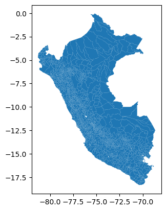

```python
# Plot a basic map of Peru to visually inspect the spatial extent
# and confirm that the geometries loaded correctly.
peru.plot()
```

**I5. Focus on the Lima departamiento**

```python
# Filter the dataset to include only districts belonging to the
# department of Lima for the analysis.
lima = peru[peru['DEPARTAMENTO'] == 'Lima']

# Display the first five rows to verify that the filtering was applied correctly.
lima.head()
```

|  | DEPARTAMENTO | PROVINCIA | DISTRITO | ubigeo | Poblacion | IDH2019 | Educ_sec_comp2019_pct | NBI2017_pct | Viv_sin_serv_hig2017_pct | geometry |
| --- | --- | --- | --- | --- | --- | --- | --- | --- | --- | --- |
| 39 | Lima | YAUYOS | ALIS | PE151002 | 1233 | 0.646897 | 69.474298 | 30.3 | 6.6 | MULTIPOLYGON (((-75.77784 -12.23272, -75.77734... |
| 40 | Lima | YAUYOS | AYAUCA | PE151003 | 2293 | 0.544152 | 43.167400 | 61.9 | 57.2 | MULTIPOLYGON (((-76.01635 -12.42245, -76.0144 ... |
| 54 | Lima | HUAURA | AMBAR | PE150802 | 2761 | 0.316448 | 42.060097 | 73.3 | 60.2 | MULTIPOLYGON (((-77.34618 -10.60763, -77.34587... |
| 65 | Lima | LIMA | ANCON | PE150102 | 42124 | 0.668889 | 72.117976 | 21.7 | 1.1 | MULTIPOLYGON (((-77.00476 -11.61427, -77.00495... |
| 71 | Lima | OYON | ANDAJES | PE150902 | 1058 | 0.488913 | 71.684369 | 36.4 | 28.5 | MULTIPOLYGON (((-76.90593 -10.66744, -76.90616... |

## **II. Neighborhood**

### **II1. Contiguity - Queen**

**II1A. Adjacency Matrix**

```python
# Creates a spatial neighbor graph using Queen contiguity.
# Each district is connected to all districts it touches (edge or vertex).
queen_lima = Graph.build_contiguity(lima, rook = False)
```

```python
# Inspect the adjacency list showing which districts are neighbors
# under Queen contiguity (for diagnostic purposes only).
queen_lima.adjacency
```

| focal | neighbor | weight |
| --- | --- | --- |
| 39 | 827 | 1 |
|  | 979 | 1 |
|  | 1726 | 1 |
|  | 1813 | 1 |
| 40 | 124 | 1 |
| ... | ... | ... |
| 1850 | 626 | 1 |
|  | 1266 | 1 |
| 1871 | 40 | 1 |
|  | 358 | 1 |
|  | 1084 | 1 |

894 rows × 1 columns

**dtype:** int64

**II1B. Adjacency Plot**

```python
# Display an interactive map to visually explore Queen contiguity relationships
# (used for exploratory purposes only, not required for analysis).
queen_lima.explore(**general_arguments)
```

Make this Notebook Trusted to load map: File -> Trust Notebook

[interactive chart not shown]

### **II2. Proximity - Nearest Neighbors (k=8)**

**II2A. Adjacency Matrix**

```python
# Build a K-nearest neighbors (KNN) spatial graph using representative points
# so that each district is connected to its 8 closest neighboring districts by distance.
knn8_lima = Graph.build_knn(lima.representative_point(), # GDF
                                 k=8) # desired k

# Display the adjacency list for the KNN graph, showing which districts
# are considered neighbors under the KNN (k=8) definition.
knn8_lima.adjacency
```

| focal | neighbor | weight |
| --- | --- | --- |
| 39 | 227 | 1 |
|  | 423 | 1 |
|  | 615 | 1 |
|  | 626 | 1 |
|  | 827 | 1 |
| ... | ... | ... |
| 1871 | 622 | 1 |
|  | 890 | 1 |
|  | 1084 | 1 |
|  | 1266 | 1 |
|  | 1698 | 1 |

1368 rows × 1 columns

**dtype:** int64

**II2B. Adjacency Plot**

```python
# Display an interactive map to visually explore the KNN (k = 8) neighborhood
# structure and inspect how districts are connected under this definition.
knn8_lima.explore(**general_arguments)
```

Make this Notebook Trusted to load map: File -> Trust Notebook

[interactive chart not shown]

### **Normalization of weights**

```python
# Transforms queen matrix from long format to wide format
toWideMatrix(queen_lima.transform("r"))
```

| neighbor focal | weight 39 | weight 40 | weight 54 | weight 65 | weight 71 | weight 86 | weight 93 | weight 102 | weight 109 | weight 110 | weight ... | weight 1726 | weight 1751 | weight 1781 | weight 1783 | weight 1797 | weight 1799 | weight 1804 | weight 1813 | weight 1850 | weight 1871 |
| --- | --- | --- | --- | --- | --- | --- | --- | --- | --- | --- | --- | --- | --- | --- | --- | --- | --- | --- | --- | --- | --- |
| 39 | 0.0 | 0.000000 | 0.0 | 0.0 | 0.0 | 0.0 | 0.0 | 0.0 | 0.0 | 0.0 | ... | 0.25 | 0.0 | 0.0 | 0.0 | 0.0 | 0.0 | 0.000000 | 0.25 | 0.000000 | 0.000000 |
| 40 | 0.0 | 0.000000 | 0.0 | 0.0 | 0.0 | 0.0 | 0.0 | 0.0 | 0.0 | 0.0 | ... | 0.00 | 0.0 | 0.0 | 0.0 | 0.0 | 0.0 | 0.083333 | 0.00 | 0.083333 | 0.083333 |
| 54 | 0.0 | 0.000000 | 0.0 | 0.0 | 0.0 | 0.0 | 0.0 | 0.0 | 0.0 | 0.0 | ... | 0.00 | 0.0 | 0.0 | 0.0 | 0.0 | 0.0 | 0.000000 | 0.00 | 0.000000 | 0.000000 |
| 65 | 0.0 | 0.000000 | 0.0 | 0.0 | 0.0 | 0.0 | 0.0 | 0.0 | 0.0 | 0.0 | ... | 0.00 | 0.0 | 0.0 | 0.0 | 0.0 | 0.0 | 0.000000 | 0.00 | 0.000000 | 0.000000 |
| 71 | 0.0 | 0.000000 | 0.0 | 0.0 | 0.0 | 0.0 | 0.0 | 0.0 | 0.0 | 0.0 | ... | 0.00 | 0.0 | 0.0 | 0.0 | 0.0 | 0.0 | 0.000000 | 0.00 | 0.000000 | 0.000000 |
| ... | ... | ... | ... | ... | ... | ... | ... | ... | ... | ... | ... | ... | ... | ... | ... | ... | ... | ... | ... | ... | ... |
| 1799 | 0.0 | 0.000000 | 0.0 | 0.0 | 0.0 | 0.0 | 0.0 | 0.0 | 0.0 | 0.0 | ... | 0.00 | 0.0 | 0.0 | 0.0 | 0.2 | 0.0 | 0.000000 | 0.00 | 0.000000 | 0.000000 |
| 1804 | 0.0 | 0.166667 | 0.0 | 0.0 | 0.0 | 0.0 | 0.0 | 0.0 | 0.0 | 0.0 | ... | 0.00 | 0.0 | 0.0 | 0.0 | 0.0 | 0.0 | 0.000000 | 0.00 | 0.000000 | 0.000000 |
| 1813 | 0.2 | 0.000000 | 0.0 | 0.0 | 0.0 | 0.0 | 0.0 | 0.0 | 0.0 | 0.0 | ... | 0.20 | 0.0 | 0.0 | 0.0 | 0.0 | 0.0 | 0.000000 | 0.00 | 0.000000 | 0.000000 |
| 1850 | 0.0 | 0.166667 | 0.0 | 0.0 | 0.0 | 0.0 | 0.0 | 0.0 | 0.0 | 0.0 | ... | 0.00 | 0.0 | 0.0 | 0.0 | 0.0 | 0.0 | 0.000000 | 0.00 | 0.000000 | 0.000000 |
| 1871 | 0.0 | 0.333333 | 0.0 | 0.0 | 0.0 | 0.0 | 0.0 | 0.0 | 0.0 | 0.0 | ... | 0.00 | 0.0 | 0.0 | 0.0 | 0.0 | 0.0 | 0.000000 | 0.00 | 0.000000 | 0.000000 |

171 rows × 171 columns

```python
# Transforms knn8 matrix from long format to wide format
toWideMatrix(knn8_lima.transform("r"))
```

| neighbor focal | weight 39 | weight 40 | weight 54 | weight 65 | weight 71 | weight 86 | weight 93 | weight 102 | weight 109 | weight 110 | weight ... | weight 1726 | weight 1751 | weight 1781 | weight 1783 | weight 1797 | weight 1799 | weight 1804 | weight 1813 | weight 1850 | weight 1871 |
| --- | --- | --- | --- | --- | --- | --- | --- | --- | --- | --- | --- | --- | --- | --- | --- | --- | --- | --- | --- | --- | --- |
| 39 | 0.000 | 0.000 | 0.0 | 0.0 | 0.0 | 0.0 | 0.0 | 0.0 | 0.0 | 0.0 | ... | 0.125 | 0.000 | 0.000 | 0.0 | 0.000 | 0.0 | 0.0 | 0.125 | 0.000 | 0.000 |
| 40 | 0.000 | 0.000 | 0.0 | 0.0 | 0.0 | 0.0 | 0.0 | 0.0 | 0.0 | 0.0 | ... | 0.000 | 0.000 | 0.000 | 0.0 | 0.000 | 0.0 | 0.0 | 0.000 | 0.125 | 0.125 |
| 54 | 0.000 | 0.000 | 0.0 | 0.0 | 0.0 | 0.0 | 0.0 | 0.0 | 0.0 | 0.0 | ... | 0.000 | 0.000 | 0.125 | 0.0 | 0.000 | 0.0 | 0.0 | 0.000 | 0.000 | 0.000 |
| 65 | 0.000 | 0.000 | 0.0 | 0.0 | 0.0 | 0.0 | 0.0 | 0.0 | 0.0 | 0.0 | ... | 0.000 | 0.000 | 0.000 | 0.0 | 0.000 | 0.0 | 0.0 | 0.000 | 0.000 | 0.000 |
| 71 | 0.000 | 0.000 | 0.0 | 0.0 | 0.0 | 0.0 | 0.0 | 0.0 | 0.0 | 0.0 | ... | 0.000 | 0.000 | 0.000 | 0.0 | 0.000 | 0.0 | 0.0 | 0.000 | 0.000 | 0.000 |
| ... | ... | ... | ... | ... | ... | ... | ... | ... | ... | ... | ... | ... | ... | ... | ... | ... | ... | ... | ... | ... | ... |
| 1799 | 0.000 | 0.000 | 0.0 | 0.0 | 0.0 | 0.0 | 0.0 | 0.0 | 0.0 | 0.0 | ... | 0.000 | 0.000 | 0.000 | 0.0 | 0.125 | 0.0 | 0.0 | 0.000 | 0.000 | 0.000 |
| 1804 | 0.000 | 0.000 | 0.0 | 0.0 | 0.0 | 0.0 | 0.0 | 0.0 | 0.0 | 0.0 | ... | 0.000 | 0.125 | 0.000 | 0.0 | 0.000 | 0.0 | 0.0 | 0.000 | 0.000 | 0.000 |
| 1813 | 0.125 | 0.000 | 0.0 | 0.0 | 0.0 | 0.0 | 0.0 | 0.0 | 0.0 | 0.0 | ... | 0.125 | 0.000 | 0.000 | 0.0 | 0.000 | 0.0 | 0.0 | 0.000 | 0.000 | 0.000 |
| 1850 | 0.000 | 0.125 | 0.0 | 0.0 | 0.0 | 0.0 | 0.0 | 0.0 | 0.0 | 0.0 | ... | 0.000 | 0.000 | 0.000 | 0.0 | 0.000 | 0.0 | 0.0 | 0.000 | 0.000 | 0.000 |
| 1871 | 0.000 | 0.125 | 0.0 | 0.0 | 0.0 | 0.0 | 0.0 | 0.0 | 0.0 | 0.0 | ... | 0.000 | 0.000 | 0.000 | 0.0 | 0.000 | 0.0 | 0.0 | 0.000 | 0.000 | 0.000 |

171 rows × 171 columns

**Spatial Lag of Queen Rule**

```python
# Display basic summary statistics for the education variable
# to inspect its distribution and check for missing values.
lima.Educ_sec_comp2019_pct.describe()
```

|  | Educ_sec_comp2019_pct |
| --- | --- |
| count | 171.000000 |
| mean | 64.528993 |
| std | 14.867417 |
| min | 12.358409 |
| 25% | 56.828850 |
| 50% | 67.618560 |
| 75% | 76.540106 |
| max | 89.215043 |

**dtype:** float64

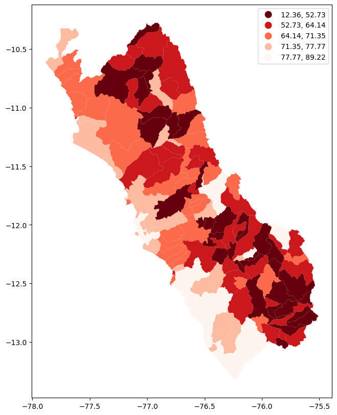

```python
# Plot a choropleth map of the education variable using quantile classification
# to visually explore its spatial distribution across districts.
lima.plot(
    "Educ_sec_comp2019_pct",
    scheme = "quantiles",
    cmap = "Reds_r",
    legend=True, figsize = (12, 10))
```

```python
# Builds a Queen contiguity spatial neighbor graph where districts are neighbors
# if they share a boundary or a corner.
lima_queen = Graph.build_contiguity(lima, rook=False)
```

```python
# Normalize the Queen spatial weights using row-standardization.
lima_queen = lima_queen.transform("r")
```

```python
# Compute the spatial lag of the education variable using Queen weights,
# representing the average value in neighboring districts.
ylag = lima_queen.lag(lima["Educ_sec_comp2019_pct"])
```

```python
# Add the spatial lag of the education variable as a new column
# representing the average value in neighboring districts.
lima = lima.assign(Educ_sec_comp2019_pct_lagged = ylag)

# Display the first rows to verify the new column was added.
lima.head()
```

|  | DEPARTAMENTO | PROVINCIA | DISTRITO | ubigeo | Poblacion | IDH2019 | Educ_sec_comp2019_pct | NBI2017_pct | Viv_sin_serv_hig2017_pct | geometry | Educ_sec_comp2019_pct_lagged |
| --- | --- | --- | --- | --- | --- | --- | --- | --- | --- | --- | --- |
| 39 | Lima | YAUYOS | ALIS | PE151002 | 1233 | 0.646897 | 69.474298 | 30.3 | 6.6 | MULTIPOLYGON (((-75.77784 -12.23272, -75.77734... | 46.580156 |
| 40 | Lima | YAUYOS | AYAUCA | PE151003 | 2293 | 0.544152 | 43.167400 | 61.9 | 57.2 | MULTIPOLYGON (((-76.01635 -12.42245, -76.0144 ... | 60.012500 |
| 54 | Lima | HUAURA | AMBAR | PE150802 | 2761 | 0.316448 | 42.060097 | 73.3 | 60.2 | MULTIPOLYGON (((-77.34618 -10.60763, -77.34587... | 54.147482 |
| 65 | Lima | LIMA | ANCON | PE150102 | 42124 | 0.668889 | 72.117976 | 21.7 | 1.1 | MULTIPOLYGON (((-77.00476 -11.61427, -77.00495... | 67.086008 |
| 71 | Lima | OYON | ANDAJES | PE150902 | 1058 | 0.488913 | 71.684369 | 36.4 | 28.5 | MULTIPOLYGON (((-76.90593 -10.66744, -76.90616... | 52.353706 |

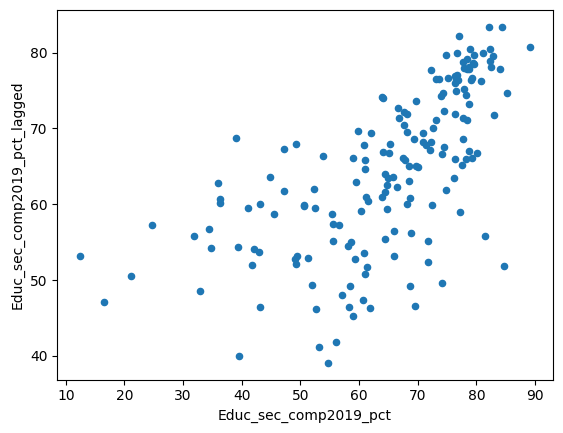

```python
# Create a Moran scatterplot showing the relationship between each district’s
# education value and the average value of its neighboring districts.
lima.plot.scatter("Educ_sec_comp2019_pct","Educ_sec_comp2019_pct_lagged")
```

**Normalization of Nearest Neighbors Rule**

```python
# Convert the row-standardized KNN spatial weights into a full matrix
# for inspection and visualization purposes.
toWideMatrix(knn8_lima.transform("r"))
```

| neighbor focal | weight 39 | weight 40 | weight 54 | weight 65 | weight 71 | weight 86 | weight 93 | weight 102 | weight 109 | weight 110 | weight ... | weight 1726 | weight 1751 | weight 1781 | weight 1783 | weight 1797 | weight 1799 | weight 1804 | weight 1813 | weight 1850 | weight 1871 |
| --- | --- | --- | --- | --- | --- | --- | --- | --- | --- | --- | --- | --- | --- | --- | --- | --- | --- | --- | --- | --- | --- |
| 39 | 0.000 | 0.000 | 0.0 | 0.0 | 0.0 | 0.0 | 0.0 | 0.0 | 0.0 | 0.0 | ... | 0.125 | 0.000 | 0.000 | 0.0 | 0.000 | 0.0 | 0.0 | 0.125 | 0.000 | 0.000 |
| 40 | 0.000 | 0.000 | 0.0 | 0.0 | 0.0 | 0.0 | 0.0 | 0.0 | 0.0 | 0.0 | ... | 0.000 | 0.000 | 0.000 | 0.0 | 0.000 | 0.0 | 0.0 | 0.000 | 0.125 | 0.125 |
| 54 | 0.000 | 0.000 | 0.0 | 0.0 | 0.0 | 0.0 | 0.0 | 0.0 | 0.0 | 0.0 | ... | 0.000 | 0.000 | 0.125 | 0.0 | 0.000 | 0.0 | 0.0 | 0.000 | 0.000 | 0.000 |
| 65 | 0.000 | 0.000 | 0.0 | 0.0 | 0.0 | 0.0 | 0.0 | 0.0 | 0.0 | 0.0 | ... | 0.000 | 0.000 | 0.000 | 0.0 | 0.000 | 0.0 | 0.0 | 0.000 | 0.000 | 0.000 |
| 71 | 0.000 | 0.000 | 0.0 | 0.0 | 0.0 | 0.0 | 0.0 | 0.0 | 0.0 | 0.0 | ... | 0.000 | 0.000 | 0.000 | 0.0 | 0.000 | 0.0 | 0.0 | 0.000 | 0.000 | 0.000 |
| ... | ... | ... | ... | ... | ... | ... | ... | ... | ... | ... | ... | ... | ... | ... | ... | ... | ... | ... | ... | ... | ... |
| 1799 | 0.000 | 0.000 | 0.0 | 0.0 | 0.0 | 0.0 | 0.0 | 0.0 | 0.0 | 0.0 | ... | 0.000 | 0.000 | 0.000 | 0.0 | 0.125 | 0.0 | 0.0 | 0.000 | 0.000 | 0.000 |
| 1804 | 0.000 | 0.000 | 0.0 | 0.0 | 0.0 | 0.0 | 0.0 | 0.0 | 0.0 | 0.0 | ... | 0.000 | 0.125 | 0.000 | 0.0 | 0.000 | 0.0 | 0.0 | 0.000 | 0.000 | 0.000 |
| 1813 | 0.125 | 0.000 | 0.0 | 0.0 | 0.0 | 0.0 | 0.0 | 0.0 | 0.0 | 0.0 | ... | 0.125 | 0.000 | 0.000 | 0.0 | 0.000 | 0.0 | 0.0 | 0.000 | 0.000 | 0.000 |
| 1850 | 0.000 | 0.125 | 0.0 | 0.0 | 0.0 | 0.0 | 0.0 | 0.0 | 0.0 | 0.0 | ... | 0.000 | 0.000 | 0.000 | 0.0 | 0.000 | 0.0 | 0.0 | 0.000 | 0.000 | 0.000 |
| 1871 | 0.000 | 0.125 | 0.0 | 0.0 | 0.0 | 0.0 | 0.0 | 0.0 | 0.0 | 0.0 | ... | 0.000 | 0.000 | 0.000 | 0.0 | 0.000 | 0.0 | 0.0 | 0.000 | 0.000 | 0.000 |

171 rows × 171 columns

**Spatial Lag of Nearest Neighbors Rule**

```python
# Build a K-nearest neighbors spatial graph (k = 8) using representative points
knn8_lima = Graph.build_knn(lima.representative_point(), k=8)

# Normalize the KNN spatial weights using row-standardization so that
# each district’s neighbor weights sum to 1.
knn8_lima = knn8_lima.transform("r")

# Compute the spatial lag of the education variable using the KNN (k=8) weights,
# representing the average value among the nearest neighboring districts.
ylag2 = knn8_lima.lag(lima["Educ_sec_comp2019_pct"])
```

```python
# Add the spatially lagged version of the education variable (based on KNN weights)
# as a new column in the GeoDataFrame.
lima = lima.assign(Educ_sec_comp2019_pct_lagged2 = ylag2)

# Display the first few rows to verify that the new lagged variable
# was added correctly to the dataset.
lima.head()
```

|  | DEPARTAMENTO | PROVINCIA | DISTRITO | ubigeo | Poblacion | IDH2019 | Educ_sec_comp2019_pct | NBI2017_pct | Viv_sin_serv_hig2017_pct | geometry | Educ_sec_comp2019_pct_lagged | Educ_sec_comp2019_pct_lagged2 |
| --- | --- | --- | --- | --- | --- | --- | --- | --- | --- | --- | --- | --- |
| 39 | Lima | YAUYOS | ALIS | PE151002 | 1233 | 0.646897 | 69.474298 | 30.3 | 6.6 | MULTIPOLYGON (((-75.77784 -12.23272, -75.77734... | 46.580156 | 50.671613 |
| 40 | Lima | YAUYOS | AYAUCA | PE151003 | 2293 | 0.544152 | 43.167400 | 61.9 | 57.2 | MULTIPOLYGON (((-76.01635 -12.42245, -76.0144 ... | 60.012500 | 62.332303 |
| 54 | Lima | HUAURA | AMBAR | PE150802 | 2761 | 0.316448 | 42.060097 | 73.3 | 60.2 | MULTIPOLYGON (((-77.34618 -10.60763, -77.34587... | 54.147482 | 58.021443 |
| 65 | Lima | LIMA | ANCON | PE150102 | 42124 | 0.668889 | 72.117976 | 21.7 | 1.1 | MULTIPOLYGON (((-77.00476 -11.61427, -77.00495... | 67.086008 | 71.730275 |
| 71 | Lima | OYON | ANDAJES | PE150902 | 1058 | 0.488913 | 71.684369 | 36.4 | 28.5 | MULTIPOLYGON (((-76.90593 -10.66744, -76.90616... | 52.353706 | 52.211993 |

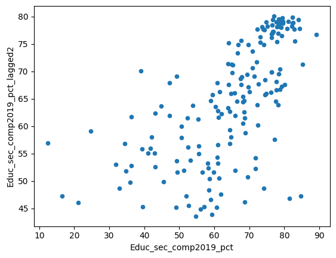

```python
# Create a Moran scatterplot showing the relationship between each district’s
# education value and the spatially lagged education value based on KNN (k = 8) weights.
lima.plot.scatter("Educ_sec_comp2019_pct","Educ_sec_comp2019_pct_lagged2")
```

### **Spatial Autocorrelation**

**Moran's LISA with `Lima_Queen`**

```python
# Run LISA (Local Moran’s I) for the education variable using Queen weights.
lisa = esda.Moran_Local(lima['Educ_sec_comp2019_pct'], lima_queen)
```

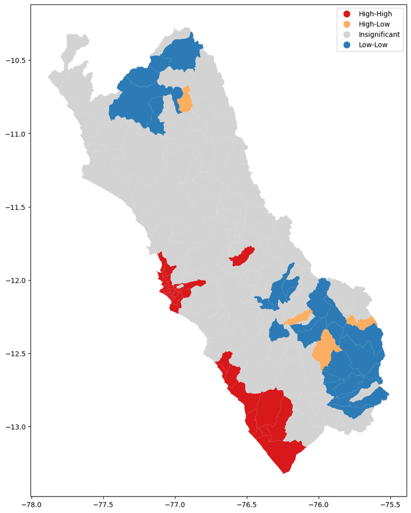

```python
# Plot the LISA cluster map using Queen weights, highlighting statistically
# significant clusters and outliers at the 0.05 significance level.
lisa.plot(lima, crit_value = 0.05, figsize = (10, 13), legend = True)
```

```python
# Get the LISA cluster (quadrant) labels for each district using Queen weights
# at the 0.05 significance level.
lima['HS_lisa_queen'] = lisa.get_cluster_labels(crit_value = 0.05)

# Display the count of districts in each LISA category
# to summarize the distribution of cluster types.
lima['HS_lisa_queen'].value_counts()
```

| HS_lisa_queen | count |
| --- | --- |
| Insignificant | 104 |
| High-High | 37 |
| Low-Low | 25 |
| High-Low | 5 |

**dtype:** int64

```python
# Define the summary statistics to compute for the education variable
TheStats = ["mean", "min", "max","var"]

# Calculate summary statistics of the education variable grouped by
# Queen-based LISA cluster category.
grouped_stats = lima.groupby('HS_lisa_queen')['Educ_sec_comp2019_pct'].agg(TheStats)

# Display the summary statistics for each LISA cluster group.
grouped_stats
```

| HS_lisa_queen | mean | min | max | var |
| --- | --- | --- | --- | --- |
| High-High | 78.540146 | 66.653554 | 89.215043 | 15.435961 |
| High-Low | 73.730855 | 68.601779 | 84.743374 | 42.516362 |
| Insignificant | 62.780815 | 16.477878 | 85.209470 | 185.994936 |
| Low-Low | 49.224536 | 12.358409 | 61.943082 | 159.714627 |

```python
# Display the unique LISA cluster categories assigned under
# the Queen contiguity neighborhood definition.
lima['HS_lisa_queen'].unique()
```

```
array(['High-Low', 'Insignificant', 'Low-Low', 'High-High'], dtype=object)
```

```python
# Define the original LISA cluster labels returned by the analysis
oldLabels = ['Insignificant', 'Low-Low', 'High-High', 'High-Low', 'Low-High']

# Define new, custom labels to rename the LISA categories for clarity and ordering
# (with 'no_pattern' placed in the middle).
newLabels = ['3 no_pattern', '4 coldSpot','2 hotSpot','1 hotOutlier' , '5 coldOutlier']

# Create a dictionary that maps the original LISA labels to the new custom labels
labels = dict(zip(oldLabels, newLabels))

# Display the label-mapping dictionary
labels
```

```
{'Insignificant': '3 no_pattern',
 'Low-Low': '4 coldSpot',
 'High-High': '2 hotSpot',
 'High-Low': '1 hotOutlier',
 'Low-High': '5 coldOutlier'}
```

```python
# Replace the original LISA cluster labels with the custom labels
# defined in the label-mapping dictionary.
lima.replace({'HS_lisa_queen':labels},inplace=True)

# Display the count of districts in each renamed LISA category,
# sorted by label order.
lima['HS_lisa_queen'].value_counts().sort_index()
```

| HS_lisa_queen | count |
| --- | --- |
| 1 hotOutlier | 5 |
| 2 hotSpot | 37 |
| 3 no_pattern | 104 |
| 4 coldSpot | 25 |

**dtype:** int64

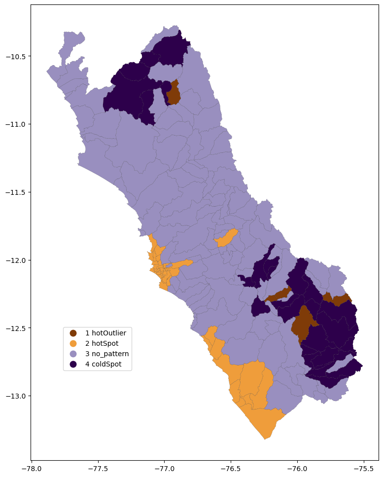

```python
# Define a categorical color map with 5 classes for visualizing
# the Queen-based LISA cluster categories.
myColMap = plt.get_cmap('PuOr', 5)

# Plot the LISA cluster map using the renamed Queen LISA categories.
# Districts are colored by cluster type with boundaries outlined for clarity.
lima.plot(column='HS_lisa_queen',
                categorical=True,
                cmap=myColMap,
                linewidth=0.1,
                edgecolor='k',
                legend=True,
                legend_kwds={'bbox_to_anchor': (0.3, 0.3)},
                figsize=(12,12))
```

### **Spatial Autocorrelation**

**Moran's LISA with `knn8_lima`**

```python
# Compute Local Moran’s I (LISA) for the education variable using
# the K-nearest neighbors (k = 8) spatial weights.
lisa_knn8 = esda.Moran_Local(lima['Educ_sec_comp2019_pct'], knn8_lima)


# Plot the LISA cluster map using K-nearest neighbors (k = 8) weights,
# highlighting statistically significant clusters and outliers at the 0.05 level.
lisa_knn8.plot(lima, crit_value = 0.05, figsize = (10, 13), legend = True)
```

[output not shown]

```python
# Get the LISA cluster (quadrant) labels for each district using
# the K-nearest neighbors (k = 8) weights at the 0.05 significance level.
lima['HS_lisa_knn8'] = lisa_knn8.get_cluster_labels(crit_value = 0.05)

# Display the count of districts in each LISA category
# for the KNN-based analysis.
lima['HS_lisa_knn8'].value_counts()
```

| HS_lisa_knn8 | count |
| --- | --- |
| Insignificant | 76 |
| High-High | 47 |
| Low-Low | 39 |
| High-Low | 8 |
| Low-High | 1 |

**dtype:** int64

```python
# Define the summary statistics to compute for the education variable
TheStats = ["mean", "min", "max","var"]

# Calculate summary statistics of the education variable grouped by
# KNN-based (k = 8) LISA cluster category.
grouped_stats = lima.groupby('HS_lisa_knn8')['Educ_sec_comp2019_pct'].agg(TheStats)

# Display the summary statistics for each KNN-based LISA cluster group.
grouped_stats
```

| HS_lisa_knn8 | mean | min | max | var |
| --- | --- | --- | --- | --- |
| High-High | 77.361237 | 66.653554 | 89.215043 | 21.677868 |
| High-Low | 73.456008 | 65.911513 | 84.743374 | 42.001032 |
| Insignificant | 64.039299 | 24.716818 | 85.209470 | 149.422530 |
| Low-High | 64.032471 | 64.032471 | 64.032471 | NaN |
| Low-Low | 48.200321 | 12.358409 | 61.943082 | 165.400348 |

```python
# Display the unique LISA cluster categories assigned under
# the K-nearest neighbors (k = 8) neighborhood definition.
lima['HS_lisa_knn8'].unique()
```

```
array(['High-Low', 'Insignificant', 'High-High', 'Low-Low', 'Low-High'],
      dtype=object)
```

```python
# Define the original LISA cluster labels produced by the KNN-based analysis
oldLabels=['Insignificant', 'Low-Low', 'High-High', 'High-Low', 'Low-High']

# Define custom labels to rename the LISA categories for clarity and ordering
# (with 'no_pattern' placed in the middle).
newLabels = ['3 no_pattern', '4 coldSpot','2 hotSpot','1 hotOutlier' , '5 coldOutlier']

# Create a dictionary mapping the original labels to the new custom labels
labels = dict(zip(oldLabels, newLabels))

# Display the label-mapping dictionary
labels
```

```
{'Insignificant': '3 no_pattern',
 'Low-Low': '4 coldSpot',
 'High-High': '2 hotSpot',
 'High-Low': '1 hotOutlier',
 'Low-High': '5 coldOutlier'}
```

```python
# Replace the original KNN-based LISA cluster labels with the custom labels
# defined in the label-mapping dictionary.
lima.replace({'HS_lisa_knn8':labels},inplace=True)

# Display the count of districts in each renamed KNN-based LISA category,
# sorted by label order.
lima['HS_lisa_knn8'].value_counts().sort_index()
```

| HS_lisa_knn8 | count |
| --- | --- |
| 1 hotOutlier | 8 |
| 2 hotSpot | 47 |
| 3 no_pattern | 76 |
| 4 coldSpot | 39 |
| 5 coldOutlier | 1 |

**dtype:** int64

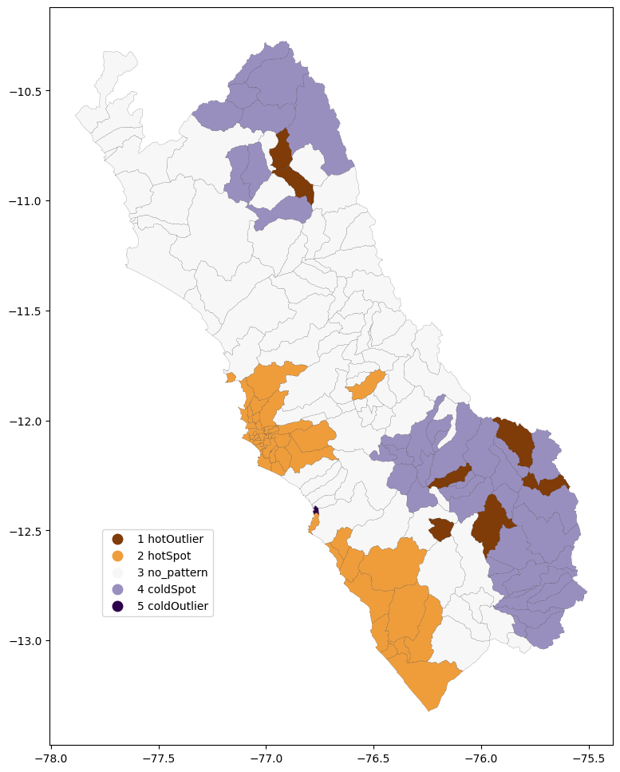

```python
# Define a categorical color map with 5 classes for visualizing
# the KNN-based (k = 8) LISA cluster categories.
myColMap2 = plt.get_cmap('PuOr', 5)

# Plot the LISA cluster map using the renamed KNN-based LISA categories.
# Districts are colored by cluster type with boundaries outlined for clarity.
lima.plot(column='HS_lisa_knn8',
                categorical=True,
                cmap=myColMap2,
                linewidth=0.1,
                edgecolor='k',
                legend=True,
                legend_kwds={'bbox_to_anchor': (0.3, 0.3)},
                figsize=(12,12))
```

### **Report**:

**Identify districts that change LISA category between Queen and KNN (k=8)**

```python
# Identify districts that change LISA category between Queen and KNN (k=8)
changed_districts = lima.loc[
    lima["HS_lisa_queen"] != lima["HS_lisa_knn8"],
    ["DISTRITO", "HS_lisa_queen", "HS_lisa_knn8"]
]

changed_districts
```

|  | DISTRITO | HS_lisa_queen | HS_lisa_knn8 |
| --- | --- | --- | --- |
| 54 | AMBAR | 4 coldSpot | 3 no_pattern |
| 224 | CARABAYLLO | 3 no_pattern | 2 hotSpot |
| 257 | CAUJUL | 4 coldSpot | 3 no_pattern |
| 315 | CHECRAS | 3 no_pattern | 1 hotOutlier |
| 390 | CIENEGUILLA | 3 no_pattern | 2 hotSpot |
| 396 | COAYLLO | 3 no_pattern | 2 hotSpot |
| 450 | COPA | 3 no_pattern | 4 coldSpot |
| 479 | CUENCA | 3 no_pattern | 4 coldSpot |
| 544 | GORGOR | 3 no_pattern | 4 coldSpot |
| 557 | HONGOS | 3 no_pattern | 4 coldSpot |
| 615 | HUANCAYA | 3 no_pattern | 1 hotOutlier |
| 621 | HUANEC | 3 no_pattern | 4 coldSpot |
| 622 | HUANGASCAR | 3 no_pattern | 4 coldSpot |
| 810 | LAHUAYTAMBO | 3 no_pattern | 4 coldSpot |
| 839 | LEONCIO PRADO | 3 no_pattern | 4 coldSpot |
| 904 | MADEAN | 3 no_pattern | 4 coldSpot |
| 948 | MARIATANA | 3 no_pattern | 4 coldSpot |
| 1022 | NAVAN | 3 no_pattern | 4 coldSpot |
| 1078 | OYON | 3 no_pattern | 4 coldSpot |
| 1093 | PACHACAMAC | 3 no_pattern | 2 hotSpot |
| 1239 | PUCUSANA | 3 no_pattern | 2 hotSpot |
| 1437 | SAN JUAN DE LURIGANCHO | 3 no_pattern | 2 hotSpot |
| 1447 | SAN LORENZO DE QUINTI | 3 no_pattern | 4 coldSpot |
| 1493 | SAN PEDRO DE PILAS | 3 no_pattern | 1 hotOutlier |
| 1511 | SANGALLAYA | 3 no_pattern | 4 coldSpot |
| 1519 | SANTA ANITA | 3 no_pattern | 2 hotSpot |
| 1540 | SANTA MARIA DEL MAR | 3 no_pattern | 5 coldOutlier |
| 1549 | SANTA ROSA | 3 no_pattern | 2 hotSpot |
| 1726 | TOMAS | 3 no_pattern | 4 coldSpot |
| 1797 | VILLA EL SALVADOR | 3 no_pattern | 2 hotSpot |
| 1799 | VILLA MARIA DEL TRIUNFO | 3 no_pattern | 2 hotSpot |
| 1813 | VITIS | 3 no_pattern | 4 coldSpot |

The following districts do not share the same LISA category when comparing Queen vs. KNN (k = 8) neighborhoods:

AMBAR; CARABAYLLO; CAUJUL; CHECRAS; CIENEGUILLA; COAYLLO; COPA; CUENCA; GORGOR; HONGOS; HUANCAYA; HUANEC; HUANGASCAR; LAHUAYTAMBO; LEONCIO PRADO; MADEAN; MARIATANA; NAVAN; OYON; PACHACAMAC; PUCUSANA; SAN JUAN DE LURIGANCHO; SAN LORENZO DE QUINTI; SAN PEDRO DE PILAS; SANGALLAYA; SANTA ANITA; SANTA MARIA DEL MAR; SANTA ROSA; TOMAS; VILLA EL SALVADOR; VILLA MARIA DEL TRIUNFO; VITIS.

*(Their Queen category and KNN category are shown in the table above.)*